# Tilastollinen Oppimisen Jatkokurssi Round 1

## Exercise 1

*In this exercise, we will predict the number of applications received using the other variables in the College data set.*

First we load the data

```r
library(ISLR)
College
```

|  | Private | Apps | Accept | Enroll | Top10perc | Top25perc | F.Undergrad | P.Undergrad | Outstate | Room.Board | Books | Personal | PhD | Terminal | S.F.Ratio | perc.alumni | Expend | Grad.Rate |
| --- | --- | --- | --- | --- | --- | --- | --- | --- | --- | --- | --- | --- | --- | --- | --- | --- | --- | --- |
| Abilene Christian University | Yes | 1660 | 1232 | 721 | 23 | 52 | 2885 | 537 | 7440 | 3300 | 450 | 2200 | 70 | 78 | 18.1 | 12 | 7041 | 60 |
| Adelphi University | Yes | 2186 | 1924 | 512 | 16 | 29 | 2683 | 1227 | 12280 | 6450 | 750 | 1500 | 29 | 30 | 12.2 | 16 | 10527 | 56 |
| Adrian College | Yes | 1428 | 1097 | 336 | 22 | 50 | 1036 | 99 | 11250 | 3750 | 400 | 1165 | 53 | 66 | 12.9 | 30 | 8735 | 54 |
| Agnes Scott College | Yes | 417 | 349 | 137 | 60 | 89 | 510 | 63 | 12960 | 5450 | 450 | 875 | 92 | 97 | 7.7 | 37 | 19016 | 59 |
| Alaska Pacific University | Yes | 193 | 146 | 55 | 16 | 44 | 249 | 869 | 7560 | 4120 | 800 | 1500 | 76 | 72 | 11.9 | 2 | 10922 | 15 |
| Albertson College | Yes | 587 | 479 | 158 | 38 | 62 | 678 | 41 | 13500 | 3335 | 500 | 675 | 67 | 73 | 9.4 | 11 | 9727 | 55 |
| Albertus Magnus College | Yes | 353 | 340 | 103 | 17 | 45 | 416 | 230 | 13290 | 5720 | 500 | 1500 | 90 | 93 | 11.5 | 26 | 8861 | 63 |
| Albion College | Yes | 1899 | 1720 | 489 | 37 | 68 | 1594 | 32 | 13868 | 4826 | 450 | 850 | 89 | 100 | 13.7 | 37 | 11487 | 73 |
| Albright College | Yes | 1038 | 839 | 227 | 30 | 63 | 973 | 306 | 15595 | 4400 | 300 | 500 | 79 | 84 | 11.3 | 23 | 11644 | 80 |
| Alderson-Broaddus College | Yes | 582 | 498 | 172 | 21 | 44 | 799 | 78 | 10468 | 3380 | 660 | 1800 | 40 | 41 | 11.5 | 15 | 8991 | 52 |

[output cut: 767 more lines]

```r
sum(is.na(College))
```

```
[1] 0
```

### (a)

*Split the data set into a training set and a test set.*

Following the same approach as in the lectures we generate the indicies for the training set and test set by sampling from the sequence 1:777. To get an approximate ratio of 80:20 training set to test set the size of the test set was set to 155. For reproducibility the seed was set to 777.

```r
N = 777
K = 155
set.seed(777)
test = sample(seq(N), K, replace=FALSE)
test
```

```
  [1] 535 382 268 771 538   9 267 133 731 192 563 506 444 455 661  80 319
 [18] 660 775 296 289 486 394 134  23 582 366 419 742 526 624 543 621 246
 [35] 218 230 555 206 512 476  16 208 434 244 159 724 657 763 675 111 484
 [52] 261  30 117 355 112  50 690 212  15 777 142 576   5 638  46 762 183
 [69] 664 435  77 546 672 757 217 637 198 466 425 272 266 331 236 704 161
 [86] 334 140 175 507 613 541  68 160 607 138 561 250 152 633 632 635 395
[103] 707  98 667 550 317 316 401 426 423 598 199 297 418 178 714 492 521
[120] 616 238 110 374 695 306 738  36 443 583 342 277 457 182 377 343 733
[137] 200 279 278 222 530 499 144  69  54   7 432 751  73 109 646  31 205
[154] 515 349
```

```r
train=seq(N)[-test]
train
```

```
  [1]   1   2   3   4   6   8  10  11  12  13  14  17  18  19  20  21  22
 [18]  24  25  26  27  28  29  32  33  34  35  37  38  39  40  41  42  43
 [35]  44  45  47  48  49  51  52  53  55  56  57  58  59  60  61  62  63
 [52]  64  65  66  67  70  71  72  74  75  76  78  79  81  82  83  84  85
 [69]  86  87  88  89  90  91  92  93  94  95  96  97  99 100 101 102 103
 [86] 104 105 106 107 108 113 114 115 116 118 119 120 121 122 123 124 125
[103] 126 127 128 129 130 131 132 135 136 137 139 141 143 145 146 147 148
[120] 149 150 151 153 154 155 156 157 158 162 163 164 165 166 167 168 169
[137] 170 171 172 173 174 176 177 179 180 181 184 185 186 187 188 189 190
[154] 191 193 194 195 196 197 201 202 203 204 207 209 210 211 213 214 215
[171] 216 219 220 221 223 224 225 226 227 228 229 231 232 233 234 235 237
[188] 239 240 241 242 243 245 247 248 249 251 252 253 254 255 256 257 258
[205] 259 260 262 263 264 265 269 270 271 273 274 275 276 280 281 282 283
[222] 284 285 286 287 288 290 291 292 293 294 295 298 299 300 301 302 303
[239] 304 305 307 308 309 310 311 312 313 314 315 318 320 321 322 323 324
```

[output cut: 22 more lines]

```r
length(test) + length(train)
```

```
[1] 777
```

### (b)

*Fit a linear model using least squares on the training set, and report the test error obtained.*

```r
fit.lm = lm(Apps ~ ., data = College[train, ])
summary(fit.lm$residuals^2)
```

```
    Min.  1st Qu.   Median     Mean  3rd Qu.     Max.
       0    28632   142407   940942   439085 51029330
```

```r
pred.lm = predict(fit.lm, College[test, ])
sqrres.lm = (pred.lm - College[test, 'Apps'])^2
summary(sqrres.lm)
```

```
     Min.   1st Qu.    Median      Mean   3rd Qu.      Max.
       51     26050    125040   1932994    507424 155227441
```

Test-MSE: 1932994  
Train-MSE: 940942

### (c)

*Fit a ridge regression model on the training set, with λ chosen by cross-validation. Report the test error obtained.*

First we need to prepare the data since we will be using the glmnet package.

```r
library(glmnet)
set.seed(777)
grid = 10^seq(5,-5, length=50)
x = model.matrix(Apps~., College)[ ,-1]
y = College$Apps
```

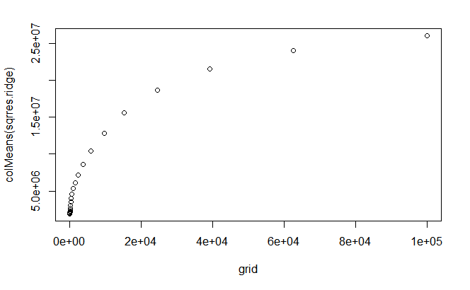

```r
fit.ridge = glmnet(x[train, ], y[train], alpha = 0, lambda = grid)
pred.ridge = predict(fit.ridge, newx = x[test, ])
sqrres.ridge = (pred.ridge - y[test])^2
plot(grid, colMeans(sqrres.ridge))
```

```r
lambda.ridge = grid[which.min(colMeans(sqrres.ridge))]
lambda.ridge
```

```
[1] 1e-05
```

```r
mean(sqrres.ridge[, which.min(colMeans(sqrres.ridge))])
```

```
[1] 1933104
```

```r
sqrres.ridgetrain = (predict(fit.ridge, s = lambda.ridge, newx = x[train, ]) - y[train])^2
mean(sqrres.ridgetrain)
```

```
[1] 940942
```

Test-MSE: 1933104  
Train-MSE: 940942

The λ chosen was also the smallest one, indicating that perhaps the unregularized model is better. The previous exercise confirms this.

If we instead wanted to do k-fold cross-validation we would use the following approach:

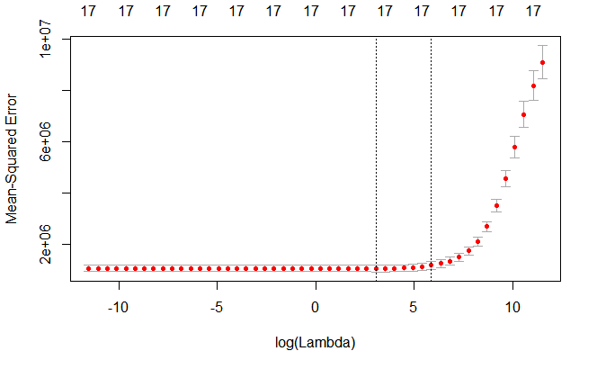

```r
set.seed(777)
fit.cvridge = cv.glmnet(x[train, ], y[train], alpha = 0, lambda = grid)
plot(fit.cvridge)
```

```r
lambda.cvridge = fit.cvridge$lambda.min
lambda.cvridge
```

```
[1] 21.20951
```

```r
trainerrors.cv = (predict(fit.cvridge, newx = x[train, ], s = lambda.cvridge)-y[train])^2
mean(trainerrors.cv)
```

```
[1] 944583.8
```

```r
pred.cvridge = predict(fit.cvridge, newx = x[test, ], s = lambda.cvridge)
sqrres.cvridge = (pred.cvridge - y[test])^2
mean(sqrres.cvridge)
```

```
[1] 2149076
```

Test-MSE: 2149076  
Train-MSE: 944583.8

Here the λ is a bit larger but test set performance is a bit worse.

### (d)

*Fit a lasso model on the training set, with λ chosen by cross-validation. Report the test error obtained, along with the number of non-zero coefficient estimates.*

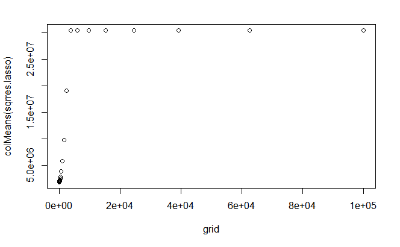

```r
fit.lasso = glmnet(x[train, ], y[train], alpha = 1, lambda = grid)
pred.lasso = predict(fit.lasso, newx = x[test, ])
sqrres.lasso = (pred.lasso - y[test])^2
plot(grid, colMeans(sqrres.lasso))
```

```r
lambda.lasso = grid[which.min(colMeans(sqrres.lasso))]
lambda.lasso
```

```
[1] 1e-05
```

```r
mean(sqrres.lasso[, which.min(colMeans(sqrres.lasso))])
```

```
[1] 1934333
```

```r
sqrres.lassotrain = (predict(fit.lasso, s = lambda.lasso, newx = x[train, ]) - y[train])^2
mean(sqrres.lassotrain)
```

```
[1] 940942.7
```

Test-MSE: 1934333 Train-MSE: 940942.7

The λ chosen was also the smallest one, indicating that perhaps the unregularized model is better.

If we instead wanted to do k-fold cross-validation we would use the following approach:

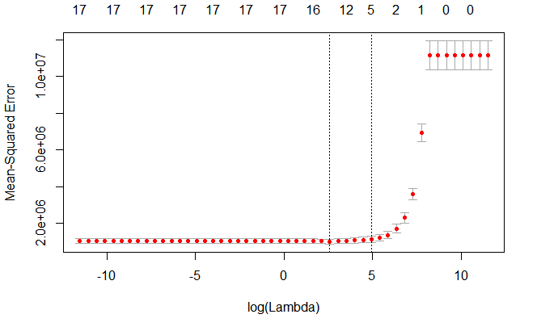

```r
set.seed(777)
fit.cvlasso = cv.glmnet(x[train, ], y[train], alpha = 1, lambda = grid)
plot(fit.cvlasso)
```

```r
lambda.cvlasso = fit.cvlasso$lambda.min
lambda.cvlasso
```

```
[1] 13.25711
```

```r
trainerrors.cv = (predict(fit.cvlasso, newx = x[train, ], s = lambda.cvlasso)-y[train])^2
mean(trainerrors.cv)
```

```
[1] 952410.1
```

```r
pred.cvlasso = predict(fit.cvlasso, newx = x[test, ], s = lambda.cvlasso)
sqrres.cvlasso = (pred.cvlasso - y[test])^2
mean(sqrres.cvlasso)
```

```
[1] 2088789
```

Test-MSE = 2088789  
Train-MSE = 952410.1

Again, the λ chosen is a bit larger with a bit worse test set performance.

```r
predict(fit.cvlasso, s = lambda.cvlasso, type = "coefficients")
```

```
18 x 1 sparse Matrix of class "dgCMatrix"
                        1
(Intercept) -5.858408e+02
PrivateYes  -6.599247e+02
Accept       1.241021e+00
Enroll       .
Top10perc    3.905267e+01
Top25perc   -8.589682e+00
F.Undergrad  4.265479e-02
P.Undergrad  3.540499e-03
Outstate    -2.751800e-02
Room.Board   1.409855e-01
Books       -3.260092e-02
Personal     .
PhD         -7.676610e+00
Terminal    -2.596574e+00
S.F.Ratio    1.457308e+01
perc.alumni -3.660714e+00
Expend       6.242808e-02
Grad.Rate    7.792752e+00
```

The Enroll and Personal variables were left out of the model.

### (g)

*Comment on the results obtained. How accurately can we predict the number of college applications received? Is there much difference among the test errors resulting from these five approaches?*

None of the tested models seem to perform much better MSE-wise on the test set.

We can compute the $R^2$-values:

```r
TSS = sum((y[test]-mean(y[test]))^2)
lm.test.r2 = 1 - sum(sqrres.lm)/TSS
ridge.test.r2 = 1 - sum(sqrres.ridge[, which.min(colMeans(sqrres.ridge))])/TSS
cvridge.test.r2 = 1 - sum(sqrres.cvridge)/TSS
lasso.test.r2 = 1 - sum(sqrres.lasso[, which.min(colMeans(sqrres.lasso))])/TSS
cvlasso.test.r2 = 1 - sum(sqrres.cvlasso)/TSS
lm.test.r2
```

```
[1] 0.9353348
```

```r
ridge.test.r2
```

```
[1] 0.9353311
```

```r
cvridge.test.r2
```

```
[1] 0.9281061
```

```r
lasso.test.r2
```

```
[1] 0.93529
```

```r
cvlasso.test.r2
```

```
[1] 0.930123
```

But we should probably be using something like adjusted-$R^2$ to compare the models.

In general the results were good and we can predict the number of applicants pretty accurately with any of the tried models.

## Exercise 2

*We will now try to predict per capita crime rate in the Boston data set.*

We first load the dataset and explore it a bit.

```r
library(glmnet)
library(ISLR)
library(MASS)
Boston
```

|  | crim | zn | indus | chas | nox | rm | age | dis | rad | tax | ptratio | black | lstat | medv |
| --- | --- | --- | --- | --- | --- | --- | --- | --- | --- | --- | --- | --- | --- | --- |
| 1 | 0.00632 | 18.0 | 2.31 | 0 | 0.5380 | 6.575 | 65.2 | 4.0900 | 1 | 296 | 15.3 | 396.90 | 4.98 | 24.0 |
| 2 | 0.02731 | 0.0 | 7.07 | 0 | 0.4690 | 6.421 | 78.9 | 4.9671 | 2 | 242 | 17.8 | 396.90 | 9.14 | 21.6 |
| 3 | 0.02729 | 0.0 | 7.07 | 0 | 0.4690 | 7.185 | 61.1 | 4.9671 | 2 | 242 | 17.8 | 392.83 | 4.03 | 34.7 |
| 4 | 0.03237 | 0.0 | 2.18 | 0 | 0.4580 | 6.998 | 45.8 | 6.0622 | 3 | 222 | 18.7 | 394.63 | 2.94 | 33.4 |
| 5 | 0.06905 | 0.0 | 2.18 | 0 | 0.4580 | 7.147 | 54.2 | 6.0622 | 3 | 222 | 18.7 | 396.90 | 5.33 | 36.2 |
| 6 | 0.02985 | 0.0 | 2.18 | 0 | 0.4580 | 6.430 | 58.7 | 6.0622 | 3 | 222 | 18.7 | 394.12 | 5.21 | 28.7 |
| 7 | 0.08829 | 12.5 | 7.87 | 0 | 0.5240 | 6.012 | 66.6 | 5.5605 | 5 | 311 | 15.2 | 395.60 | 12.43 | 22.9 |
| 8 | 0.14455 | 12.5 | 7.87 | 0 | 0.5240 | 6.172 | 96.1 | 5.9505 | 5 | 311 | 15.2 | 396.90 | 19.15 | 27.1 |
| 9 | 0.21124 | 12.5 | 7.87 | 0 | 0.5240 | 5.631 | 100.0 | 6.0821 | 5 | 311 | 15.2 | 386.63 | 29.93 | 16.5 |
| 10 | 0.17004 | 12.5 | 7.87 | 0 | 0.5240 | 6.004 | 85.9 | 6.5921 | 5 | 311 | 15.2 | 386.71 | 17.10 | 18.9 |

[output cut: 496 more lines]

```r
sum(is.na(Boston))
```

```
[1] 0
```

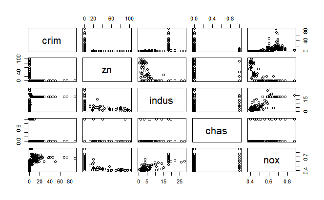

```r
plot(Boston[, 1:5])
```

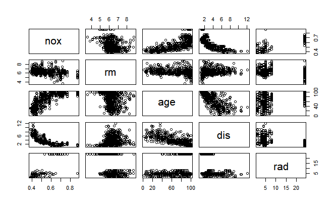

```r
plot(Boston[, 5:9])
```

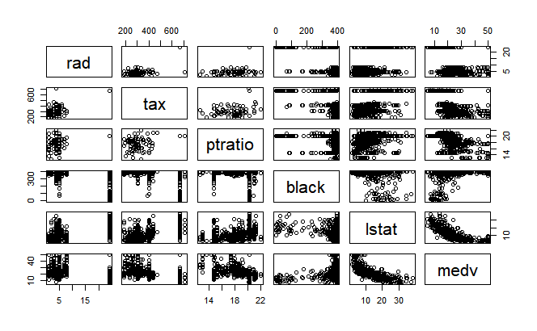

```r
plot(Boston[, 9:14])
```

### (a)

*Try out some of the regression methods explored in this chapter, such as best subset selection, the lasso, ridge regression, and PCR. Present and discuss results for the approaches that you consider.*

First we split into training and testing sets:

```r
N = 506
K = 101
set.seed(777)
test = sample(seq(N), K, replace=FALSE)
test
```

```
  [1] 349 249 174 501 350   6 173  86 473 124 364 327 287 294 427  52 205
 [18] 425 172 190 185 312 253 499  15 373 234 268 474 335 398 346 395 157
 [35] 139 146 353 131 324 301  10 469 274 154 101 456 414 416 424  70 304
 [52] 164  19  73 222 457  31 430 132 466 333  89 358   3 396  29  50 113
 [69] 411 269  48 337 460 178 133 391 122 286 260 167 163 202 144 176  99
 [86] 203  85 106 308 372 328  41  97 367  84 338 150  91 380 408 381
```

```r
train=seq(N)[-test]
train
```

```
  [1]   1   2   4   5   7   8   9  11  12  13  14  16  17  18  20  21  22
 [18]  23  24  25  26  27  28  30  32  33  34  35  36  37  38  39  40  42
 [35]  43  44  45  46  47  49  51  53  54  55  56  57  58  59  60  61  62
 [52]  63  64  65  66  67  68  69  71  72  74  75  76  77  78  79  80  81
 [69]  82  83  87  88  90  92  93  94  95  96  98 100 102 103 104 105 107
 [86] 108 109 110 111 112 114 115 116 117 118 119 120 121 123 125 126 127
[103] 128 129 130 134 135 136 137 138 140 141 142 143 145 147 148 149 151
[120] 152 153 155 156 158 159 160 161 162 165 166 168 169 170 171 175 177
[137] 179 180 181 182 183 184 186 187 188 189 191 192 193 194 195 196 197
[154] 198 199 200 201 204 206 207 208 209 210 211 212 213 214 215 216 217
[171] 218 219 220 221 223 224 225 226 227 228 229 230 231 232 233 235 236
[188] 237 238 239 240 241 242 243 244 245 246 247 248 250 251 252 254 255
[205] 256 257 258 259 261 262 263 264 265 266 267 270 271 272 273 275 276
[222] 277 278 279 280 281 282 283 284 285 288 289 290 291 292 293 295 296
[239] 297 298 299 300 302 303 305 306 307 309 310 311 313 314 315 316 317
[256] 318 319 320 321 322 323 325 326 329 330 331 332 334 336 339 340 341
[273] 342 343 344 345 347 348 351 352 354 355 356 357 359 360 361 362 363
[290] 365 366 368 369 370 371 374 375 376 377 378 379 382 383 384 385 386
[307] 387 388 389 390 392 393 394 397 399 400 401 402 403 404 405 406 407
[324] 409 410 412 413 415 417 418 419 420 421 422 423 426 428 429 431 432
[341] 433 434 435 436 437 438 439 440 441 442 443 444 445 446 447 448 449
[358] 450 451 452 453 454 455 458 459 461 462 463 464 465 467 468 470 471
[375] 472 475 476 477 478 479 480 481 482 483 484 485 486 487 488 489 490
[392] 491 492 493 494 495 496 497 498 500 502 503 504 505 506
```

```r
length(test) + length(train)
```

```
[1] 506
```

```r
x = model.matrix(crim~., Boston)[ ,-1]
y = Boston$crim
TSS = sum((y[test] - mean(y[test]))^2)
grid = 10^seq(5,-5, length=50)
```

Simple linear model:

```r
fit.lm = lm(crim ~ ., data = Boston[train, ])
summary(fit.lm$residuals^2)
```

```
    Min.  1st Qu.   Median     Mean  3rd Qu.     Max.
   0.000    0.559    2.507   29.604    8.159 3212.708
```

```r
pred.lm = predict(fit.lm, Boston[test, ])
sqrres.lm = (pred.lm - Boston[test, 'crim'])^2
summary(sqrres.lm)
```

```
    Min.  1st Qu.   Median     Mean  3rd Qu.     Max.
   0.001    0.575    3.698   85.419   15.077 5888.016
```

```r
lm.test.r2 = 1 - sum(sqrres.lm)/TSS
lm.test.r2
```

```
[1] 0.277101
```

Ridge regression using validation set cross-validation:

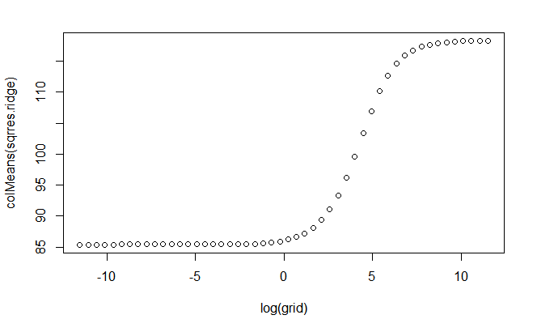

```r
fit.ridge = glmnet(x[train, ], y[train], alpha = 0, lambda = grid)
pred.ridge = predict(fit.ridge, newx = x[test, ])
sqrres.ridge = (pred.ridge - y[test])^2
plot(log(grid), colMeans(sqrres.ridge))
```

```r
lambda.ridge = grid[which.min(colMeans(sqrres.ridge))]
lambda.ridge
```

```
[1] 1e-05
```

```r
mean(sqrres.ridge[, which.min(colMeans(sqrres.ridge))])
```

```
[1] 85.41951
```

```r
sqrres.ridgetrain = (predict(fit.ridge, s = lambda.ridge, newx = x[train, ]) - y[train])^2
mean(sqrres.ridgetrain)
```

```
[1] 29.60364
```

```r
ridge.test.r2 = 1 - sum(sqrres.ridge[, which.min(colMeans(sqrres.ridge))])/TSS
ridge.test.r2
```

```
[1] 0.2770954
```

Using 10-fold crossvalidation:

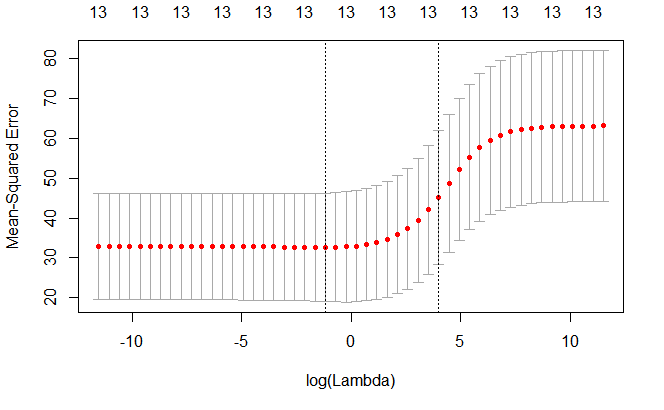

```r
set.seed(777)
fit.cvridge = cv.glmnet(x[train, ], y[train], alpha = 0, lambda = grid)
plot(fit.cvridge)
```

```r
lambda.cvridge = fit.cvridge$lambda.min
lambda.cvridge
```

```
[1] 0.3088844
```

```r
trainerrors.cv = (predict(fit.cvridge, newx = x[train, ], s = lambda.cvridge)-y[train])^2
mean(trainerrors.cv)
```

```
[1] 29.80748
```

```r
pred.cvridge = predict(fit.cvridge, newx = x[test, ], s = lambda.cvridge)
sqrres.cvridge = (pred.cvridge - y[test])^2
mean(sqrres.cvridge)
```

```
[1] 85.59521
```

```r
cvridge.test.r2 = 1 - sum(sqrres.cvridge)/TSS
cvridge.test.r2
```

```
[1] 0.2756084
```

Lasso regression:

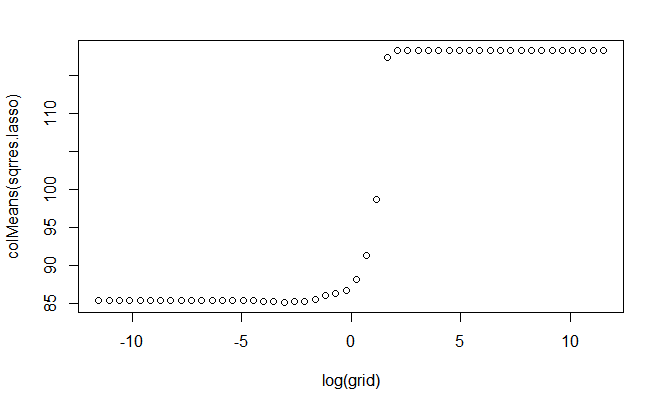

```r
fit.lasso = glmnet(x[train, ], y[train], alpha = 1, lambda = grid)
pred.lasso = predict(fit.lasso, newx = x[test, ])
sqrres.lasso = (pred.lasso - y[test])^2
plot(log(grid), colMeans(sqrres.lasso))
```

```r
lambda.lasso = grid[which.min(colMeans(sqrres.lasso))]
lambda.lasso
```

```
[1] 0.04714866
```

```r
mean(sqrres.lasso[, which.min(colMeans(sqrres.lasso))])
```

```
[1] 85.18284
```

```r
sqrres.lassotrain = (predict(fit.lasso, s = lambda.lasso, newx = x[train, ]) - y[train])^2
mean(sqrres.lassotrain)
```

```
[1] 29.74644
```

```r
lasso.test.r2 = 1 - sum(sqrres.lasso[, which.min(colMeans(sqrres.lasso))])/TSS
lasso.test.r2
```

```
[1] 0.2790984
```

Using 10-fold cross-validation:

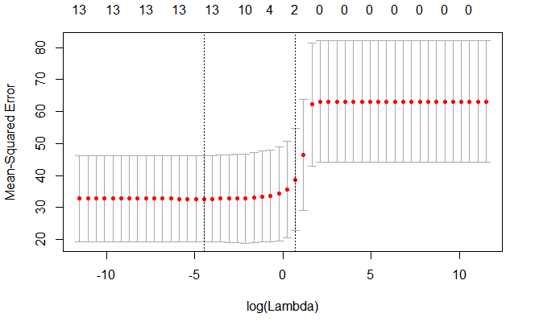

```r
set.seed(777)
fit.cvlasso = cv.glmnet(x[train, ], y[train], alpha = 1, lambda = grid)
plot(fit.cvlasso)
```

```r
lambda.cvlasso = fit.cvlasso$lambda.min
lambda.cvlasso
```

```
[1] 0.01151395
```

```r
trainerrors.cv = (predict(fit.cvlasso, newx = x[train, ], s = lambda.cvlasso)-y[train])^2
mean(trainerrors.cv)
```

```
[1] 29.61226
```

```r
pred.cvlasso = predict(fit.cvlasso, newx = x[test, ], s = lambda.cvlasso)
sqrres.cvlasso = (pred.cvlasso - y[test])^2
mean(sqrres.cvlasso)
```

```
[1] 85.32381
```

```r
cvlasso.test.r2 = 1 - sum(sqrres.cvlasso)/TSS
cvlasso.test.r2
```

```
[1] 0.2779053
```

Selecting larger $\lambda$ (fit.cvlasso$lambda.lse only returns NULL?):

```r
set.seed(777)
#lambda.cvlassolse = fit.cvlasso$lambda.lse
#lambda.cvlassolse
lambda.cvlassolse = fit.cvlasso$lambda[24]
lambda.cvlassolse
```

```
[1] 2.02359
```

```r
trainerrors.cv = (predict(fit.cvlasso, newx = x[train, ], s = lambda.cvlassolse)-y[train])^2
mean(trainerrors.cv)
```

```
[1] 37.46266
```

```r
pred.cvlassolse = predict(fit.cvlasso, newx = x[test, ], s = lambda.cvlassolse)
sqrres.cvlassolse = (pred.cvlassolse - y[test])^2
mean(sqrres.cvlassolse)
```

```
[1] 91.30182
```

```r
cvlassolse.test.r2 = 1 - sum(sqrres.cvlassolse)/TSS
cvlassolse.test.r2
```

```
[1] 0.2273134
```

```r
predict(fit.cvlasso, s = lambda.cvlassolse, type = "coefficients")
```

```
14 x 1 sparse Matrix of class "dgCMatrix"
                      1
(Intercept) -0.87318852
zn           .
indus        .
chas         .
nox          .
rm           .
age          .
dis          .
rad          0.33327356
tax          .
ptratio      .
black        .
lstat        0.09341294
medv         .
```

Best subset selection by 10-fold cross-validation:

```r
library(leaps)
predict.regsubsets = function(object, newdata, id, ...){
  form = as.formula(object$call[[2]])
  mat = model.matrix(form, newdata)
  coefi = coef(object, id = id)
  mat[, names(coefi)]%*%coefi
}
set.seed(777)
folds = sample(1:10, size=nrow(Boston[train, ]), replace=TRUE)
table(folds)
```

```
folds
 1  2  3  4  5  6  7  8  9 10
44 40 44 48 40 38 40 41 32 38
```

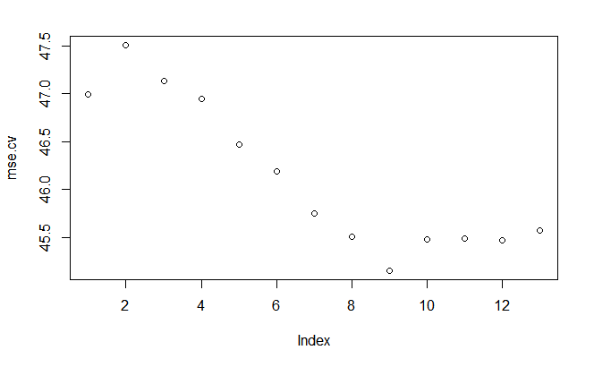

```r
cv.errors = matrix(NA, 10, 13)
for (k in 1:10) {
  best.fit = regsubsets(crim~., data = Boston[folds != k, ], nvmax=13, method='forward')
  for (i in 1:13) {
    pred = predict(best.fit, Boston[folds == k, ], id = i)
    cv.errors[k, i] = mean((Boston$crim[folds == k] - pred)^2)
  }
}
mse.cv = apply(cv.errors, 2, mean)
plot(mse.cv) # Suggests a model with 9 variables.
```

```r
model = regsubsets(crim~., data = Boston[train, ], nvmax=9, method='forward')
summ = summary(model)
summ$rsq
```

```
[1] 0.4405789 0.4900426 0.5020087 0.5066528 0.5090708 0.5133078 0.5227946
[8] 0.5241302 0.5252204
```

```r
summ$outmat
```

```
         zn  indus chas nox rm  age dis rad tax ptratio black lstat medv
1  ( 1 ) " " " "   " "  " " " " " " " " "*" " " " "     " "   " "   " "
2  ( 1 ) " " " "   " "  " " " " " " " " "*" " " " "     " "   "*"   " "
3  ( 1 ) " " " "   " "  " " " " " " " " "*" " " " "     "*"   "*"   " "
4  ( 1 ) " " "*"   " "  " " " " " " " " "*" " " " "     "*"   "*"   " "
5  ( 1 ) " " "*"   " "  " " " " " " " " "*" " " " "     "*"   "*"   "*"
6  ( 1 ) " " "*"   " "  " " " " " " "*" "*" " " " "     "*"   "*"   "*"
7  ( 1 ) "*" "*"   " "  " " " " " " "*" "*" " " " "     "*"   "*"   "*"
8  ( 1 ) "*" "*"   " "  " " " " " " "*" "*" "*" " "     "*"   "*"   "*"
9  ( 1 ) "*" "*"   " "  "*" " " " " "*" "*" "*" " "     "*"   "*"   "*"
```

```r
finalfit = lm(crim ~ zn + indus + nox + dis + rad + tax + black + lstat + medv, data = Boston[train, ])
summary(finalfit$residuals^2)
```

```
    Min.  1st Qu.   Median     Mean  3rd Qu.     Max.
   0.000    0.649    2.400   29.794    8.359 3213.119
```

```r
pred.finalfit = predict(finalfit, Boston[test, ])
sqrres.finalfit = (pred.finalfit - Boston[test, 'crim'])^2
summary(sqrres.finalfit)
```

```
    Min.  1st Qu.   Median     Mean  3rd Qu.     Max.
   0.000    0.460    4.103   85.101   13.408 5876.185
```

```r
finalfit.test.r2 = 1 - sum(sqrres.finalfit)/TSS
finalfit.test.r2
```

```
[1] 0.2797933
```

### (b)

*Propose a model (or set of models) that seem to perform well on this data set, and justify your answer. Make sure that you are evaluating model performance using validation set error, crossvalidation, or some other reasonable alternative, as opposed to using training error.*

I would choose the model suggested by the best-subset search, that is, a linear model with 9 components specified below:

```r
finalfit = lm(crim ~ zn + indus + nox + dis + rad + tax + black + lstat + medv, data = Boston[train, ])
summary(finalfit$residuals^2)
```

```
    Min.  1st Qu.   Median     Mean  3rd Qu.     Max.
   0.000    0.649    2.400   29.794    8.359 3213.119
```

```r
pred.finalfit = predict(finalfit, Boston[test, ])
sqrres.finalfit = (pred.finalfit - Boston[test, 'crim'])^2
summary(sqrres.finalfit)
```

```
    Min.  1st Qu.   Median     Mean  3rd Qu.     Max.
   0.000    0.460    4.103   85.101   13.408 5876.185
```

```r
finalfit.test.r2 = 1 - sum(sqrres.finalfit)/TSS
finalfit.test.r2
```

```
[1] 0.2797933
```

It performed well with 10-fold cross-validation and also well on the test set but is still a simpler model than the ones suggested by ridge/lasso methods.

### (c)

*Does your chosen model involve all of the features in the data set? Why or why not?*

No, the ones with more features performed worse in 10-fold cross-validation and isntead this one was picked.